# Coding to `code::proof`: Practice fundamentals of automated tests for collaborative data analysis development

# 13 Code with intent

When we think of an algorithm, it’s easy to feel overwhelmed by the complexity. And, analogous to the pitfalls of the piano student, a developer may fall prey to the inevitable rabbit holes and distractions that arise. It’s tempting to consider these distractions benign, but, in fact, these actions are frequently the result of techinical anxiety about the task, and are anathema to mastering the technique in question.

## 13.1 Practice with intent

In learning Bach’s Contrapunctus I, the student has various conventional, albeit questionable, methods of approach.

The student might begin from the start each time. But, as the piece is not yet mastered, the student will inevitably encounter something they cannot play with ease. This is often encountered in the first bar of a Bach piece. If the student plays up to the mistake, and begins again, then they risk becoming adept the start, and becoming increasingly anxious about the end of the piece.  
In an advanced piece such as Contrapunctus I, there are many challenging technical aspects. In particular, the work is polyphonic; Contrapunctus I is a central focus of the string quartet in Vikram Seth’s *An Equal Music* [todo citation]. There is a melody; formally referred to as a *subject*.

> Piano teachers know that students must practice musically in order to acquire technique. Both musicality and technique require accuracy and control. Practically any technical flaw can be detected in the music. Nonetheless, many students tend to practice neglecting the music, preferring to “work” when no one is around to listen. Their reasoning is, “I’ll practice non- musically (which is easier because you can shut off the brain) until I can play it well, then I’ll add the music.” This never works because learning piano is all about training the brain, not finger calisthenics (Chang 2009).

## 13.2 Mindful coding

Here are the relationships between inputs, and just some of the estimators, and outputs in `varameta`, presented as a randomised *graph*, a visual representation of a set of nodes, $V$, and the edges, $V \times V$, between them. We understand each function’s inputs and outputs, but understanding the way they relate to each other, is often muddled without planning. Our `code::brain`, the way we conceptulaise the code, is disorganised.

`code::brain` before `c::r`.

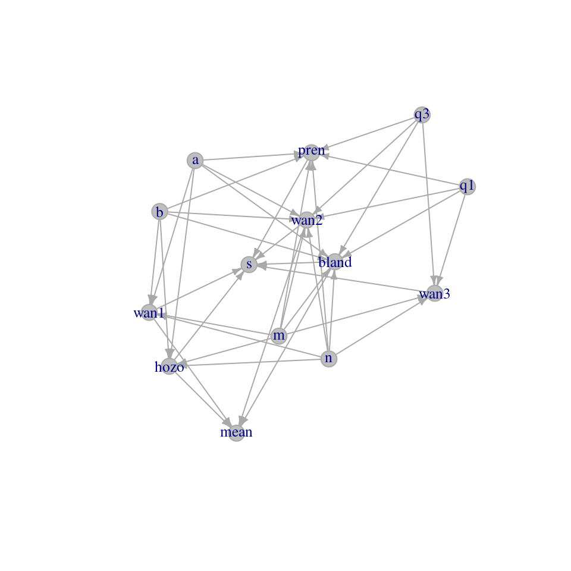

To code::register an algorithm:

# 14 `code::registration (c::r)`

In an issue on GitHub:

1. Describe the algorithm’s intended purpose.
2. Describe the input parameters and how they will be tested.
3. Describe the output parameters and how they will be tested.

Update the c::r as needed.

## 14.1 For complex projects

### 14.1.1 On a piece of paper.

1. Draw a diagram of the inputs and outputs of the algorithm.
2. Draw where this algorithm fits in the pipeline of the package, if appropriate.

### 14.1.2 Write issue

1. Describe the algorithm’s intended purpose.
2. Describe the input parameters and how they will be tested.
3. Describe the output parameters and how they will be tested.

### 14.1.3 Sketch-diagram

An image or diagram is very help, if not burdonsomely time consuming (but it often is). This section is only useful for those who enjoy graph theory and visualisation, and is not essential.

For those comfortable with *graphs* understood as mathematical objects as a set of vertices from $V$, and a set of edges $V \times V$, there are visualisation options where the vertices can be tagged with attributes. The code for constructing the following `nodes` and `edges` dataframes has been omitted for brevity, but all code can be found in this manuscript’s associated repository [`neet`](https://github.com/softloud/neet) on GitHub.

```r
library(tidyverse)
library(ggraph)
library(tidygraph)
```

By tagging the nodes in this graph with the attribute `state` in the algorithm: starting with `input` for the estimators, sample quartiles (which we denote $a, q1, m, q3, b$, in order from smallest to largest); `estimator`, a collection of functions that provide statistical methods for preparing summary medians for meta-analysis; and the `output` of the estimator.

```r
nodes
```

```
## # A tibble: 24 x 2
##    node    state
##    <chr>   <fct>
##  1 a       input
##  2 b       input
##  3 q1      input
##  4 q3      input
##  5 m       input
##  6 n       input
##  7 hozo    estimator
##  8 pren_c3 estimator
##  9 pren_c1 estimator
## 10 bland   estimator
## # … with 14 more rows
```

Edges are specified by a two-column dataframe, `edges`, where each row contains a `to` and `from` vertex identifier, the row number of the `nodes` dataframe.

```r
edges
```

```
## # A tibble: 84 x 2
##     from    to
##    <dbl> <dbl>
##  1     5     7
##  2     6     7
##  3     1     7
##  4     2     7
##  5     7    15
##  6     7    16
##  7     5    11
##  8     6    11
##  9     1    11
## 10     2    11
## # … with 74 more rows
```

These two dataframes cone be converted into a graph object that is compatible with the `igraph::` package and `tidyverse::` syntax.

```r
graph <- tbl_graph(nodes, edges)
```

`code::brain` after `c::r`.

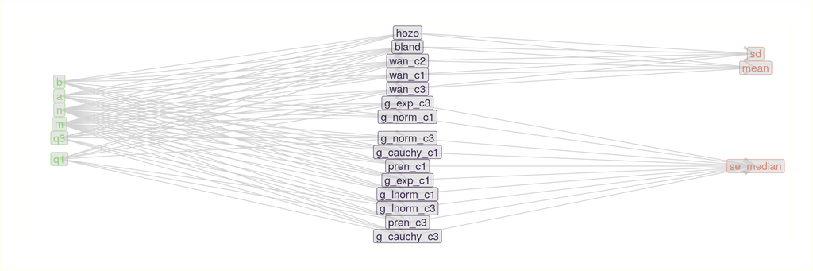

```r
graph %>%
  mutate(state = fct_relevel(state, "output")) %>%
  ggraph() +
  geom_edge_link(arrow = arrow(), colour = "lightgrey") +
  geom_node_label(aes(label = node, colour = state),
                  size = 5,
                  fill = "lightgrey",
                  alpha = 0.6) +
  theme_graph() +
  hrbrthemes::scale_color_ipsum() +
  theme(legend.position = "none",
        panel.background = element_rect(colour = "#ffffe0"),
        plot.background = element_rect(colour = "#ffffe0")) +
  scale_y_reverse() +
  coord_flip()
```

# 15 Workflow for algorithmic structure

- hard to find ap lace t ostart

The `neet::` package is part of this manuscript’s research compendia, we think of compendia, a collection of components that form a research project. In the case of this manuscript, there is an extension package of `testthat::`.

```r
# install devtools
install.packages(devtools)

# use devtools to install package from github
devtools::install_github("softloud/neet")
```

## 15.1 Test-driven workflow

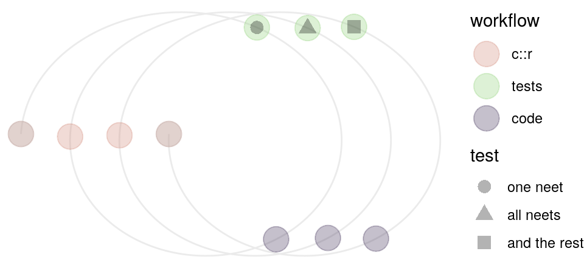

The model workflow includes three stages, repeated three times, before returning to the start, the `c::r`.

Each phase consists of:

1. `c::r`
2. tests
3. code

## 15.2 `code::proof` workflow for coding to doneness

The tests vary each time in complexity, so that the complete model cycle consists of ten phases of work:

1. `c::r`
2. neet tests, one per function
3. code
4. `c::r`
5. neet tests, for all inputs for each function
6. code
7. `c::r`
8. tests, and the rest, i.e., any other cases to test for
9. code
10. `c::r`

We use *model* cycle to denote the workflow may be adapted for different use-cases. Our next section steps through each phase of work.

## 15.3 Coding to `code::proof` toolchain walkthrough

- `varameta::`, an in-development analysis that has seen many iterations.
- `simeta::`
- `repliCATS`

# 16 First cycle: one `neet` test per function

For the first `code::proof` cycle, we follow the steps:

1. A rough, first-draft `c::r`.
2. Write one `neet` test per function.
3. Write code to make those `neet` tests pass, for each function.

If functions are written, then we only need *confirm* the functions pass the `neet` tests.

## 16.1 `c::r`

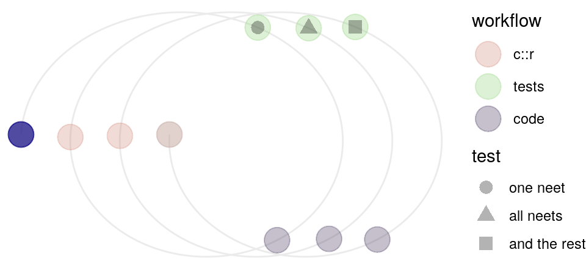

```r
neet::workflow(1)
```

We begin with a sketch outline of a `c::r`, which we then populate with description in prose, provide some detail of neet testing, before providing case-study.

As our first testing objective is one neet test per function, we need not necessarily work out the details of all possible things to check for. We simply ask, what will it take to check that each function required for the algorithm produces a non-empty thing of expected type?

```
1. Objective:

2. Inputs:

- [ ] one neet
- [ ] all neets
- [ ] and the rest

3. Outputs:

- [ ] one neet
- [ ] all neets
- [ ] and the rest
```

Note that `- [ ]` will create an unchecked tickbox and `- [x]` will create a tickbox in both GitHub and RMarkdown.

In the examples below, in the interets of brevity, we will drop the tick boxes, and provide the roughly descriptive prose for the three sections of each `c::r`. Under this workflow, we expect to update the `c::r` as our understanding of the algorithmic structure becomes more nuanced.

## 16.2 `aggreCAT:: c::r`

# 17 Second cycle: `neet` tests for all inputs

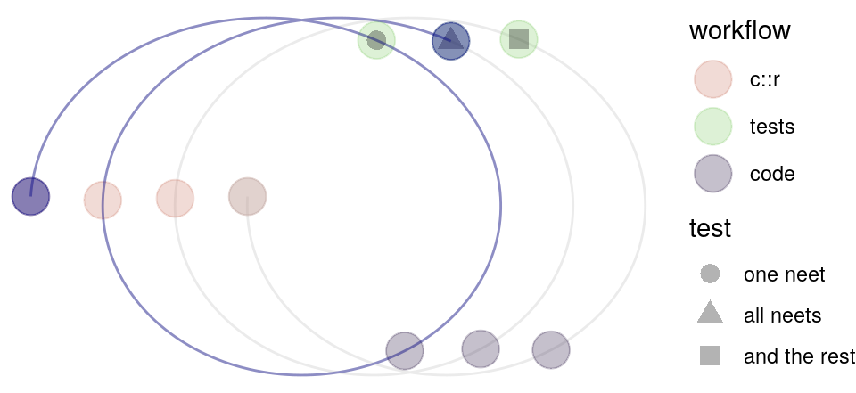

```r
workflow(5)
```

Once we have established there is one `neet` test per function, we might now perform `neet` tests for each possibility for inputs.

### 17.0.1 `c::r`

Update or rewrite `c::r`, as needed.

### 17.0.2 `neet` tests for all inputs

### 17.0.3 Coding to `code::proof`

# 18 Third cycle: Testing for doneness

### 18.0.1 `c::r`

Update or rewrite `c::r`, as needed.

### 18.0.2 All tests required for purpose

### 18.0.3 Coding to `code::proof`

## 18.1 `c::r` of doneness

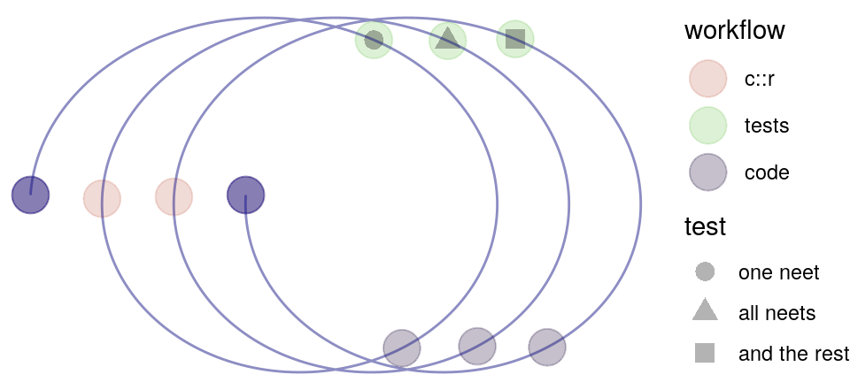

```r
workflow(10)
```

Under this workflow, the `c::r` is the project overview any developer can return to. So, this final registration not only summarises what has been tested, but also notes any idiosyncrasies for other developers, *expeically* the future self of the developer, who recalls so little of the code they may as well be a different developer.

If the algorithm does not yet have sufficient `code::proof`, the cycle can be repeated, and `c::r`s updates.

# 19 Sufficient `code::proof` of software for doneness

It does not feel a great leap to assume that we none of us will think of every use case, every aspect, of solving an algorithm computationally. Thus, rather than disputing what is or is not *done*, we simply set out to achieve *what we can think of doing*. A `c::r` provides a summary of what we could think of doing to ‘further the process of scientific discovery’, as Devezer *et al.* might put it (Devezer et al. 2019), towards our goal.

The first version of this manuscript, itself, is a preregistration of a computational workflow. This workflow is for `team reprocat::` of The repliCATS Project to develop rerproducible algorithms more happily together. The first version provides a description of the workflow for the team; the second version incorporates the team’s feedback. This arguably literalises the scientific practices of publishing manuscripts; no manuscript, no matter how definitive, provides everything required for a resaerch project, but may offer particular tools and evidence to further the process of scientific discovery.

Another researcher software engineer may be cognisant of a tool you are unfamiliar with. By providing the package, and the `c::r`, we provide a method to facilitate what Stodden describes as the *extensibility* of the algorithm (Stodden, Borwein, and Bailey 2013).

The workflow presented in this manuscript aims to address: `code::xiety`, the anxiety associating with programming; *good enough* scientific practices, by incorporating automated testing (Wilson et al. 2017); and collaborative benefits. `c::r` provides a means of providing accessibility and transparency to the next developer. *Especially* if the next developer is your future self.

# References

Bryan, Jennifer. 2017. “Excuse Me, Do You Have a Moment to Talk About Version Control?” *PeerJ PrePrints* 5: e3159.

Chang, Chuan C. 2009. *Fundamentals of Piano Practice*.

Devezer, Berna, Luis G. Nardin, Bert Baumgaertner, and Erkan Ozge Buzbas. 2019. “Scientific Discovery in a Model-Centric Framework: Reproducibility, Innovation, and Epistemic Diversity.” *PLOS ONE* 14 (5): e0216125. https://doi.org/10.1371/journal.pone.0216125.

Fraser, Hannah, Tim Parker, Shinichi Nakagawa, Ashley Barnett, and Fiona Fidler. 2018. “Questionable Research Practices in Ecology and Evolution.” *PLOS ONE* 13 (7): e0200303. https://doi.org/10.1371/journal.pone.0200303.

Galway, James. 1990. *Flute*. Kahn & Averill.

Gray, Charles T. 2019. “Code::Proof: Prepare for Most Weather Conditions.” In *Statistics and Data Science*, edited by Hien Nguyen, 22–41. Communications in Computer and Information Science. Singapore: Springer. https://doi.org/10.1007/978-981-15-1960-4_2.

Hayes, Alex. 2019. “Testing Statistical Software - Aleatoric.” Blog.

Hester, Jim. 2016. “Covr: Bringing Test Coverage to R.”

Karp, Paul. 2019. “Robodebt: The Federal Court Ruling and What It Means for Targeted Welfare Recipients.” *The Guardian*, November.

Marwick, Ben, Carl Boettiger, and Lincoln Mullen. 2018. “Packaging Data Analytical Work Reproducibly Using R (and Friends).” e3192v2. PeerJ Inc. https://doi.org/10.7287/peerj.preprints.3192v2.

McIlroy, T. 2017. “20,000 People Sent Centrelink ‘Robo-Debt’ Notices Found to Owe Less or Nothing.” *Canberra Times* 13.

Riederer, Emily. 2019. “RMarkdown Driven Development (RmdDD).” *Emily Riederer*.

“RStudio Cloud.” n.d. https://rstudio.cloud/learn/primers.

Stodden, Victoria, Jonathan Borwein, and David H. Bailey. 2013. “"Setting the Default to Reproducible” in Computational Science Research.” *SIAM News* 46 (5).

Wickham, H. 2015. *R Packages: Organize, Test, Document, and Share Your Code*. O’Reilly Media.

Wilson, Greg, D. A. Aruliah, C. Titus Brown, Neil P. Chue Hong, Matt Davis, Richard T. Guy, Steven H. D. Haddock, et al. 2014. “Best Practices for Scientific Computing.” Edited by Jonathan A. Eisen. *PLoS Biology* 12 (1): e1001745. https://doi.org/10.1371/journal.pbio.1001745.

Wilson, Greg, Jennifer Bryan, Karen Cranston, Justin Kitzes, Lex Nederbragt, and Tracy K. Teal. 2017. “Good Enough Practices in Scientific Computing.” Edited by Francis Ouellette. *PLOS Computational Biology* 13 (6): e1005510. https://doi.org/10.1371/journal.pcbi.1005510.

Yuan, Ding, Yu Luo, Xin Zhuang, Guilherme Renna Rodrigues, Xu Zhao, Yongle Zhang, Pranay U. Jain, and Michael Stumm. 2014. “Simple Testing Can Prevent Most Critical Failures: An Analysis of Production Failures in Distributed Data-Intensive Systems.” In *Proceedings of the 11th USENIX Conference on Operating Systems Design and Implementation*, 249–65. OSDI’14. Broomfield, CO: USENIX Association.